# Cleaning Raw Files in R

OpenSDP

April 24, 2018

## Intro

This tutorial has two objectives. The first objective is to demonstrate the process of cleaning a raw data file from start to finish. This includes checking and cleaning key variables, formatting, coding, renaming, and labeling variables, exploring data structure, and applying decision rules to simplify data where necessary.

You can group the cleaning operations into two parts: first, “column cleaning,” or examining, formatting, cleaning and labeling each variable as appropriate; and second, “row cleaning,” or examining the data’s structure and retaining or editing specific observations or groups of observations, with the goal of making the data internally consistent and simplifying its structure if necessary. In both column cleaning and row cleaning, you’ll need to make trade-offs between retaining all the information in the original raw dataset, and making changes to the data to make it tractable for later analysis.

Because the tutorial shows how to clean test score data, after doing row cleaning it ends with a demonstration of how to use the reshape function to change the structure of the data from “long” format to “wide” format–from one record per student per test to one record per student per year, with multiple test score variables. The end result is a cleaned file that is ready to be merged with other cleaned data files to build an analysis file.

The second objective of this tutorial is to to demonstrate some features of R which are critical for writing efficient code, including loops `dplyr` data pipelines (`%>%`). It also demonstrates the syntax for a number of functions needed for data cleaning–for example, functions to convert data to and from string format, recode variables, and convert variables into the R date format.

The code used in this tutorial is necessarily specific to the particular dataset being cleaned, in this case a file of synthetic student test scores. Thus the overall cleaning process shown is only partially generalizable to other raw data files. Test score files from other sources will typically need to be cleaned somewhat differently because of differences in structure, variables, missingness, data formats, and other issues. Other types of data, for example student demographics or enrollment files, typically require different types of data checks and cleaning operations.

This tutorial assumes that you have completed the Data Exploration, Combining Files, and Nearly Unique tutorials in the OpenSDP Data Janitor series, and that you are comfortable opening, editing, saving, and running an R Rmd file. Even if you haven’t completed those tutorials, though, you will still be able to work through this one. If any of the R functions are unfamiliar to you, type `?` followed by the name of the function in the R Console to get more information.

The Data Janitor tutorial series does not explicitly deal with questions of good coding style. When you are drawing on what you have learned from the series to write your own R scripts, you’ll quickly discover that developing and adhering to a consistent set of style guidelines will make your code easier to read, edit, and understand. Train yourself to use white space (blank lines), indentation, and comments consistently in your code. Comments, indicated in R by a `#`, are ignored by R but are critical for explaining each step of a program to human readers. The `Rmd` format also allows you to separate code from content, allowing you to add descriptions and explanations to contextualize code further, and embed R output seamlessly in a larger narrative as this tutorial demonstrates.

Work through this file one or a few lines at a time, reading the comments and making sure you understand what each “chunk” of code does. As you work, explore the data to see how the data cleaning functions change the data. The tutorial includes some data exploration functions to verify that the data edits work as intended, but feel free to perform additional interactive checks or make edits to this file.

## Getting Started

To get started, first save the tutorial file under a new name.

–> Choose “File > Save as…” under the RStudio window file menu, and replace the “XX” in the filename with your initials.

This will ensure that you won’t overwrite the original tutorial file if you decide to make edits and save them. Note that you can save files by pressing Control/Cmd + S and you should do this regularly as you are working.

You should load, edit, and then save data (using a new filename for the cleaned data) with functions in a file like this one, so that you will always be able to generate the same cleaned files from your raw data files and will have a record of your work.

### Set Up

Start the R session with a series of setup commands.

```r
set.seed(24105)
library(knitr)
library(dplyr)
library(lubridate)
library(ggplot2)
opts_chunk$set(warning = FALSE, message = FALSE)
```

The `set.seed()` function provides a seed for R’s random number functions. You can give it any integer value, and if someone uses the same integer value, their random number generator in R will produce the same results. It ensures that R will perform random actions, such as choosing a record sort order when values are tied, in the same way each time functions are run.

The `library()` function loads any third-party libraries that you want to use. For this tutorial we will use the `dplyr` library to provide access to powerful and intuitive data wrangling functions in R. If you do not have a library installed, you can always install it using the `install.packages()` function, such as `install.packages("dplyr")`.

The `opts_chunk()` function controls the output of the R Markdown document when you compile it to HTML or PDF.

An important feature to be aware of at this point is the “History” pane in the RStudio window. You can use this rerun commands, view all commands from the current session, or export all commands to an output log file.

Next, get ready to load the data. You will be loading five years of raw test score data from a fictitious large school district. This data includes all the test scores for all assessments, but you are particularly interested in the state math and ELA test scores for students in grades 3-8.

Often when you clean a raw data file of data extracted from a student information system or other source, you review and clean each of the variables but keep the basic structure of the file the same. In the case of transactional data like test scores, though, there are extra steps before you can merge the data with other files into an analysis file. You will need to restrict the sample and restructure of the data. Your goal is to make a cleaned test score file with one record per student per year. The file should include only math and ELA state test scores for students in grades 3 through 8.

## Load the Data

Often you will receive raw data in separate annual text files, in comma delimited format. When that happens, you can use the `read.csv()` function to read the files into R. In this case the raw data is already in a single R-formatted file. Load the data and explore the file to review the variables and their formats.

```r
load("data/assess.rda")
str(assess)
```

```
## 'data.frame':    448362 obs. of  12 variables:
##  $ reporting_year : chr  "2006" "2006 " "2006" "2006" ...
##  $ collection_code: chr  "FDS" " FDS" " FDS" "FDS" ...
##  $ extraction_date: chr  "20061027" "20061027" "20061027" "20061027" ...
##  $ student_id     : chr  "121203515" "391039135" "261090339" "181200766" ...
##  $ test_id        : chr  "ALG1" "ALG1" "ALG1" "ALG1" ...
##  $ test_date      : chr  "20060601" "20060601" "20060101" "20060601" ...
##  $ score          : chr  "139" "42" "139" "139" ...
##  $ ach_level      : chr  "1" "1" "1" "1 " ...
##  $ cscore         : chr  "-1.366" "-1.898" "-1.287" "-1.527" ...
##  $ cscore_err     : chr  "0" "0" "0" "" ...
##  $ accommodation  : chr  NA NA NA NA ...
##  $ fake_data      : chr  "1" "1" "1" "1" ...
```

```r
summary(assess)
```

```
##  reporting_year     collection_code    extraction_date
##  Length:448362      Length:448362      Length:448362
##  Class :character   Class :character   Class :character
##  Mode  :character   Mode  :character   Mode  :character
##   student_id          test_id           test_date
##  Length:448362      Length:448362      Length:448362
##  Class :character   Class :character   Class :character
##  Mode  :character   Mode  :character   Mode  :character
##     score            ach_level            cscore
##  Length:448362      Length:448362      Length:448362
##  Class :character   Class :character   Class :character
##  Mode  :character   Mode  :character   Mode  :character
##   cscore_err        accommodation       fake_data
##  Length:448362      Length:448362      Length:448362
##  Class :character   Class :character   Class :character
##  Mode  :character   Mode  :character   Mode  :character
```

```r
View(assess)
```

You can see from your quick review that all the variables are strings, and that some seem to have extra spaces. You can use the `trimws()` function to strip away the extra spaces.

Identify an example in the data:

```r
head(assess$collection_code)
```

```
## [1] "FDS"  " FDS" " FDS" "FDS"  "FDS"  "FDS"
```

It’s probably quickest to just apply the function to all of the variables. Here’s the syntax to loop through all the variables and trim them.

```r
for(var in names(assess)){
  assess[, var] <- trimws(assess[, var])
}
```

Here the syntax `names(assess)` refers to a vector that includes the names of all the variables in the dataset. The loop replaces the text `var` with each variable name in the dataset. The `trimws()` function is silent, so to verify changes you will want to inspect the data.

```r
head(assess$collection_code)
```

```
## [1] "FDS" "FDS" "FDS" "FDS" "FDS" "FDS"
```

Anytime you are performing the same operation on a number of variables, it’s usually worth writing a loop. R includes a number of features to make loops easier to write. The most common of these are the `apply()` functions:

```r
assess <- as.data.frame(
                apply(assess, 2, trimws)
                )
```

The `apply()` function creates a loop, the `2` tells R to operate the loop on the columns (`1` would be operations on rows), and the `trimws()` specifies the function to apply to each column or row. Using `apply()` and other functions we will introduce below, you will rarely need to write a loop in R. However, it is helpful to understand how loops work, because the `apply()` functions are essentially syntactic shortcuts for loops.

If you want to monitor the progress of your loop, you need to create `print` statements in the loop to tell R when to print to the console. This is especially helpful when you have long-running loops allowing you to monitor progress.

```r
for(var in names(assess)){
  print(var)
  assess[, var] <- trimws(assess[, var])
}
```

```
## [1] "reporting_year"
## [1] "collection_code"
## [1] "extraction_date"
## [1] "student_id"
## [1] "test_id"
## [1] "test_date"
## [1] "score"
## [1] "ach_level"
## [1] "cscore"
## [1] "cscore_err"
## [1] "accommodation"
## [1] "fake_data"
```

Now, R will print out the name of the variable it is currently working on at each phase of the loop.

## Clean the Variables

Getting back to data cleaning, now that the variables are trimmed, it’s possible to check and see if all the variables are necessary and meaningful. First check to see which years of data are included in the file, and then check the distribution of some of the variables that you suspect may be uninteresting.

```r
table(assess$reporting_year, useNA = "always")
```

```
##
##   2006   2007   2008   2009   2010   <NA>
##  77712  83642  93740 101940  91328      0
```

```r
table(assess$reporting_year, assess$collection_code, useNA = "always")
```

```
##
##           EOY    FDS   <NA>
##   2006      0  77712      0
##   2007      0  83642      0
##   2008      0  93740      0
##   2009      0 101940      0
##   2010  91328      0      0
##   <NA>      0      0      0
```

```r
table(assess$reporting_year, assess$extraction_date, useNA = "always")
```

```
##
##               20061027 20070830   <NA>
##   2006      0    77712        0      0
##   2007      0        0    83642      0
##   2008  93740        0        0      0
##   2009 101940        0        0      0
##   2010  91328        0        0      0
##   <NA>      0        0        0      0
```

The variables `collection_code` and `extraction_date` do not add additional detail beyond the `reporting_year` variable for our purposes (to analyze student annual test scores), so it’s okay to drop them.

```r
assess$collection_code <- NULL
assess$extraction_date <- NULL
```

Go through the remaining variables one at a time to examine their distribution and format. Rename them according to Strategic Data Project variable naming conventions and reformat them as necessary. (Develop your own conventions for variable names when you are cleaning your own data–make them informative and try to be consistent in how you name variables across projects.)

After the individual variables are cleaned and formatted (column cleaning), you’ll do a second cleaning pass to restrict the sample to the tests of interest, apply decision rules to simplify the structure of the data (row cleaning), and then reshape the data from one record per student per test to one record per student per year.

Start by cleaning up the `reporting_year` variable. We are going to change the name of this variable to something with more meaning to us: `school_year`. According to the person who pulled the data for you, this corresponds to school year (using the convention that the school year is referred to by the calendar year of the spring semester). You’ll verify this is true for the tests you are interested in after you have cleaned the test date variable and can compare test year and school year. School year will be one of the key variables of your cleaned data file, so it is good that there are no missing values.

```r
table(assess$reporting_year, useNA = "always")
```

```
##
##   2006   2007   2008   2009   2010   <NA>
##  77712  83642  93740 101940  91328      0
```

```r
# Convert to numeric
assess$reporting_year <- as.numeric(assess$reporting_year)
# Rename
assess$school_year <- assess$reporting_year
# Drop old variable
assess$reporting_year <- NULL
```

Then `student_id`:

```r
assess$sid <- as.numeric(assess$student_id)
assess$student_id <- NULL
head(assess$sid)
```

```
## [1] 121203515 391039135 261090339 181200766 134232730 212094053
```

Before we proceed, let’s take a pause. A best practice when cleaning data like this is to make some changes to modify the data, then reload the original data and run all of your code to that point to make sure that all of the changes you made are captured in your syntax file. The Rmd format and RStudio makes this very easy.

First, you want to clear everything in your existing workspace. To do this you can either click the “broom” icon in the Environment pane, or you can run the function `rm(list = ls())` in the console.

Caution: *When you do this, everything in your environment will be removed from memory.*

After you have cleared objects from memory, you still have all the packages loaded. When you start using projects with multiple packages loaded, the interactions between these packages can compromise reproducibility. To ensure your code works, make sure to start a fresh R session and run your code again. This will help you catch errors, like forgetting to include a `library()` call in your syntax file, which will make it difficult for others to recreate your work. You can restart R by either selecting “Restart R” from the Session tab in RStudio or by typing Ctrl + Shift + F10.

To run the code up to the place you are at, you can go to the play button of the code chunk and select the icon to the left to “run all code above this chunk”, and then run the current chunk with the play button icon.

Do this process now before continuing. Using this process to write or review code–writing and running a few lines at a time, until you find a time when you need to “reset” your work by running everything from the beginning–is pretty typical.

```r
head(assess$sid, 20)
```

```
##  [1] 121203515 391039135 261090339 181200766 134232730 212094053 155112413
##  [8] 254099925 342138884 119092690 312164089 353151696 269145481 299056130
## [15] 115170944 271154249 278089016 346099800 233103761 235010558
```

Next, examine and label the test ID variable. Using the sort option puts the most common tests at the top.

```r
sort(
  table(assess$test_id, useNA = "always"),
  decreasing=TRUE)
```

```
##
##  RD03  MA03  ALG1  RD05  MA05  ENGL  RD04  RD08  MA08  COMP  RD07  RD06
## 19825 19321 19313 18815 18685 18645 18468 18309 18118 18044 18023 17916
##  MA04  MA06  MA07  CECO  BIOL  USHI  GEOM  ALG2  WR10  SC05  MA3P  SC08
## 17904 17685 17408 17229 16982 14810 14005 13717 12882 12076 11040 10937
##  RD3P  WR04  WR07  CHEM  PSCI  CTAM  CTAR  CSCM  CSPF  PHYS  MA10  RD10
##  9943  8366  7895  5306  4696  2798  2582  2351  2113  1526   537    90
##  CSKA  WR11  <NA>
##     1     1     0
```

```r
table(assess$test_id, assess$school_year, useNA = "always")
```

```
##
##        2006 2007 2008 2009 2010 <NA>
##   ALG1 3232 3693 4002 4150 4236    0
##   ALG2 2228 2431 2826 2829 3403    0
##   BIOL 2819 3063 3401 3662 4037    0
##   CECO 2948 3219 3426 3441 4195    0
##   CHEM 1626    0 1826 1854    0    0
##   COMP 2872 4402 5219 5551    0    0
##   CSCM 1064  781  397  109    0    0
##   CSKA    0    1    0    0    0    0
##   CSPF 1014  736  249  114    0    0
##   CTAM 1425  752  440  181    0    0
##   CTAR 1357  693  389  143    0    0
##   ENGL 3074 3428 3876 3921 4346    0
##   GEOM 2404 2668 2749 2943 3241    0
##   MA03 3092 3772 3912 4126 4419    0
##   MA04 3039 3246 3450 4062 4107    0
##   MA05 3105 3576 3778 4102 4124    0
##   MA06 3073 3193 3238 4034 4147    0
##   MA07 3027 3193 3268 3923 3997    0
##   MA08 2930 3486 3732 4055 3915    0
##   MA10  192  164  138   43    0    0
##   MA3P  650 3328 3505 3557    0    0
##   PHYS  455    0  519  552    0    0
##   PSCI  900    0 1151 1165 1480    0
##   RD03 3093 3670 3798 4478 4786    0
##   RD04 3007 3221 3450 4380 4410    0
##   RD05 3057 3384 3621 4329 4424    0
##   RD06 3062 3170 3256 4210 4218    0
##   RD07 2999 3179 3257 4222 4366    0
##   RD08 2919 3354 3577 4268 4191    0
##   RD10   90    0    0    0    0    0
##   RD3P 3072 3315    0 3556    0    0
##   SC05    0    0 3156 4391 4529    0
##   SC08    0    0 3036 3881 4020    0
##   USHI 2487 2756 2872 3075 3620    0
##   WR04 2582 2797 2987    0    0    0
##   WR07 2478 2607 2810    0    0    0
##   WR10 2340 2364 2429 2633 3116    0
##   WR11    0    0    0    0    1    0
##   <NA>    0    0    0    0    0    0
```

Using the sort option puts the most common tests at the top. You can see that some of the test IDs seem to consist of a subject prefix followed by a grade level (for example, MA04 for fourth-grade math, or RD06 for sixth-grade reading). Others (ALG1 for algebra 1 and ALG2 for algebra 2, and USHI for US History) don’t follow this format. Others you probably can’t identify just from the test ID; you’d need to get additional information from the district to identify those tests.

This raises a typical question in data cleaning: should you clean all the data you receive, or focus on the variables (columns) and observations (rows) that you think are most important for your analysis? If you are too hasty in working with data that you don’t yet know well, you might mistakenly drop variables or records that you need, that help you understand the dataset, or that you might want later for a different project. On the other hand, data cleaning is labor-intensive, and it doesn’t make sense to do unnecessary work. If you have limited time, a very rough rule of thumb is to try to clean all the records you receive, but focus effort on the most important variables.

In the case of test score data, though, there’s a twist if you are applying this rule of thumb. You’re likely to be reshaping the data from test level to student level, so that test scores for different tests become different variables for a given student record in the cleaned data file. If you don’t actually need all the test scores for every subject for every student, there is a reasonable argument to be made for keeping and cleaning only the records for tests you are interested in.

In this case, we’ll stipulate that you only want the data for state Mathematics and English/Language Arts tests scores for grades 3-8, and that the person who extracted the data for you told you that the IDs for the state math and ELA tests are prefixed by “MA” and “RD”. You’ll use this information later when you restrict the data and then parse the test IDs to extract the subject and grade level.

For now, keep data for all the tests during the “column cleaning” part of the data cleaning process, in case the additional tests yield some insights into the patterns of values for the other variables. We’ll wait to drop the additional tests until the beginning of the “row cleaning” process.

Convert the `test_date` variable to the R date format. R does a good job of parsing date strings in different formats to define date variables, but you do need to tell it the order of year, month, and day. Dates are very tricky to handle in any language so always be careful and check that your data is converted correctly.

```r
str(assess$test_date)
```

```
##  chr [1:448362] "20060601" "20060601" "20060101" "20060601" "20060601" ...
```

```r
as.Date(head(assess$test_date), format = "%Y %m %d")
```

```
## [1] "2006-06-01" "2006-06-01" "2006-01-01" "2006-06-01" "2006-06-01"
## [6] "2006-06-01"
```

It looks safe to make the change:

```r
assess$test_date <- as.Date(assess$test_date, format = "%Y %m %d")
```

Check to make sure that all of the test dates fall in the correct school years. The R `lubridate` package makes it fairly easy to extract years or months from date variables using the `lubridate::year()` and `lubridate::month()` functions:

```r
assess$testyear <- year(assess$test_date)
table(assess$testyear)
```

```
##
##  2005  2006  2007  2008  2009  2010
##  8438 80850 80462 97009 90597 91006
```

```r
assess$testyear[month(assess$test_date) > 6] <-
  assess$testyear[month(assess$test_date) > 6] + 1
table(assess$testyear, assess$school_year)
```

```
##
##          2006   2007   2008   2009   2010
##   2006  77712      0      0      0      0
##   2007      0  83642      1      0      0
##   2008      0      0  93739      0      0
##   2009      0      0      0 101940      0
##   2010      0      0      0      0  91328
```

There is one case where the test year and school year are different. Examine this record. It is for a test occurring in June that you don’t intend to keep.

```r
assess[assess$testyear != assess$school_year,]
```

```
##       test_id  test_date score ach_level cscore cscore_err accommodation
## 94713    CSPF 2007-06-01    47         2                 3          <NA>
##       fake_data school_year       sid testyear
## 94713         1        2008 359158275     2007
```

```r
# Drop the testyear variable now
assess$testyear <- NULL
```

Let’s verify:

```r
table(is.na(assess$test_date)) # No NA values created
```

```
##
##  FALSE
## 448362
```

```r
table(assess$test_date)
```

```
##
## 2005-07-01 2005-09-01 2005-10-01 2005-11-01 2005-12-01 2006-01-01
##         86       3722        834       1742       2054       8462
## 2006-03-01 2006-04-01 2006-05-01 2006-06-01 2006-07-01 2006-08-01
##       8246       1728      30540      20298        145          8
## 2006-09-01 2006-10-01 2006-11-01 2006-12-01 2007-01-01 2007-03-01
##       6643       1199       1300       2281       8029       8740
## 2007-04-01 2007-05-01 2007-06-01 2007-07-01 2007-08-01 2007-09-01
##       1022      33245      21031        306          2       3505
## 2007-10-01 2007-11-01 2007-12-01 2008-01-01 2008-03-01 2008-04-01
##       1087       2008       1487      10466       8848        754
## 2008-05-01 2008-06-01 2008-07-01 2008-07-10 2008-07-20 2008-08-01
##      30805      34471         80          4          2          9
## 2008-09-01 2008-10-01 2008-11-01 2008-12-01 2009-01-01 2009-01-10
##       7113        947       1681       1829      10294        318
## 2009-01-20 2009-03-01 2009-04-01 2009-05-01 2009-05-10 2009-06-01
##        178       3063        880      29746       7457      34184
## 2009-06-10 2009-06-20 2009-07-01 2009-07-10 2009-07-20 2010-01-01
##       3977        178        219         89         14       9195
## 2010-01-10 2010-03-01 2010-05-01 2010-05-10 2010-06-01 2010-06-10
##       1540       3117      28733       6920      35391       6110
```

Looks good. Now, tidy up the variable order.

```r
assess <- assess %>% select(sid, school_year, test_id, test_date,
                            everything()) %>% as.data.frame()
```

Examine the score variable. It is still stored as a string. You can use the `as.numeric()` function to coerce a string to a numeric variable. Any values that are not clearly numbers (e.g. “AA”, “”, or even “3532,23.232”) will be replaced with an NA. We can use this to rename and convert the variable in the same line.

```r
assess$scale_score <- as.numeric(assess$score)
assess$score <- NULL
```

We will want to verify that this is done correctly before dropping the original score. Let’s look at the original value of the score value where the numeric version has been replaced with NA.

```r
table(assess$score[is.na(assess$scale_score)])
```

```
## < table of extent 0 >
```

```r
assess$score <- NULL
```

An important part of cleaning test score data is examining histograms of the test scores, to check for normal distributions, ceiling and floor effects, improperly labeled tests, missing values miscoded as zeros, changes in ranges, etc. We could do this here, but instead we’ll wait until the data has been reshaped, because it will be somewhat easier to generate graphs for each subject, year and grade then.

Next, clean the achievement level variable. Achievement levels are ordered, but they are not equally spaced, which we can see in the crosstabs, so this is a good use of the R `factor` data type. In this case, you have the levels but not the descriptions - we don’t know which level is “better”. This is a fairly common data cleaning situation, and the the best approach is to do research or reach out to your contacts to acquire the missing information and then incorporate it. This helps you build a “self-documenting” dataset.

Here we’ll stipulate that the descriptions for achievement levels are consistent across tests and years: novice, developing, proficient, and advanced. Check the distribution of achievement levels by test ID to make sure they are reasonable. Destring and label the variable.

```r
table(assess$ach_level, useNA = "always")
```

```
##
##             1      2      3      4   <NA>
##   8250  44384  86239 180059 129430      0
```

```r
assess$ach_level <- factor(assess$ach_level, exclude = "",
                           labels = c("Novice", "Developing", "Proficient",
                                      "Advanced"), ordered = TRUE)
str(assess$ach_level)
```

```
##  Ord.factor w/ 4 levels "Novice"<"Developing"<..: 1 1 1 1 1 1 1 1 1 1 ...
```

```r
table(assess$ach_level, useNA = "always")
```

```
##
##     Novice Developing Proficient   Advanced       <NA>
##      44384      86239     180059     129430       8250
```

The `factor()` function allows us to created a labeled, ordered, vector of categorical data. First, we exclude the `""` category, which will code these values as `NA`. Then, we specify the labels for each level of the variable as it appears in the table output, so 1 = “Novice”, 2 = “Developing”, etc. Then we tell R we want to represent this as an `ordered` factor, which will provide us some conveniences in plotting and tabulating this variable.

Next examine the `cscore` variable:

```r
# Destring
assess$cscore <- as.numeric(assess$cscore)
summary(assess$cscore)
```

```
##    Min. 1st Qu.  Median    Mean 3rd Qu.    Max.    NA's
##   -3.93   -0.45    0.33    0.29    1.08    3.86   83465
```

You don’t have information about the cscore and cscore_err variables, but based on the cscore range, cscore may be a standardized version of the scaled test score. Standardized scores are typically centered close to 0 and range from -4 to 4.

```r
cor(assess$cscore, assess$scale_score, use = "pairwise")
```

```
## [1] 0.0481719
```

The overall correlation between scaled scores and cscores is very low–this makes sense, since different tests have different ranges, and those ranges may also change across years.

Checking the correlations by test and year, they are for the most part very close, confirming that cscore is a version of the test score.

```r
assess %>% group_by(test_id, school_year) %>%
  summarize(test_cor = cor(scale_score, cscore, use = "pairwise")) %>%
  View()
```

A few of the tests have very low cscore correlations. Examine two of these graphically, along with a test with a high correlation for comparison.

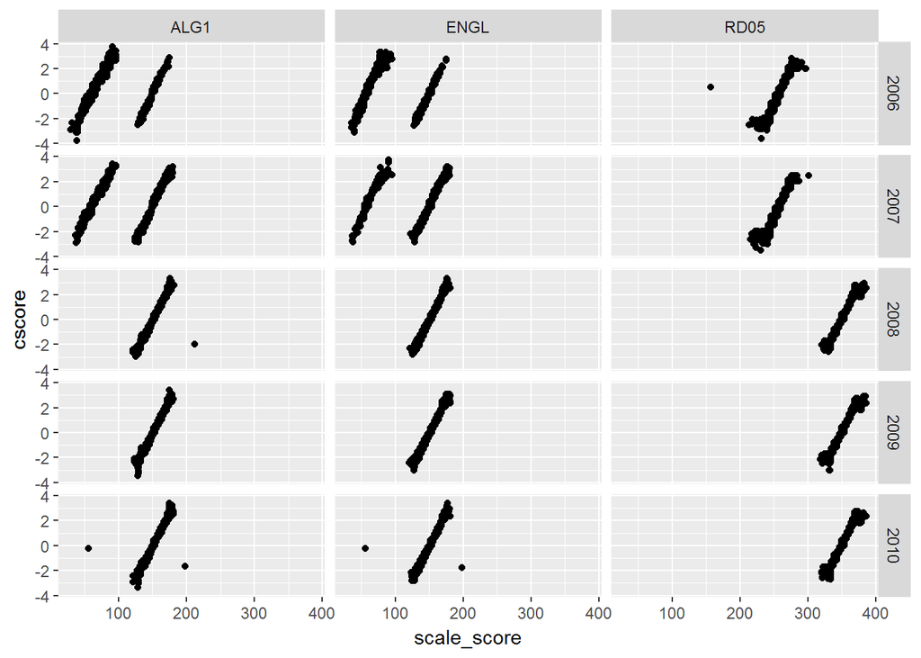

```r
plotdf <- assess %>% filter(test_id %in% c("ALG1", "RD05", "ENGL")) %>%
  select(test_id, school_year, scale_score, cscore) %>% as.data.frame()

ggplot(plotdf, aes(x = scale_score, y = cscore)) +
  geom_point() + # make a scatterplot
  facet_grid(school_year~test_id) # facet the scatters by year and test subject
```

To examine the graphs, make the graph window full screen so it’s easier to see the individual graphs. The explanation for the low correlation is clear: the problematic tests and years appear to have two different score ranges. It’s likely that scores for two different versions of the tests were lumped together in the data. If you planned to use these tests in your analysis, you would need to find out more details about the test forms and versions for the problematic tests and years.

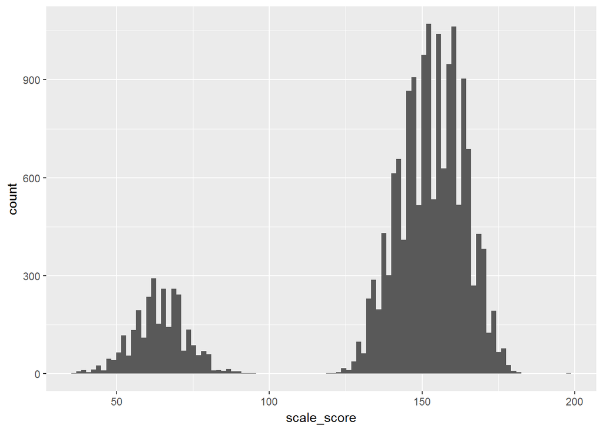

```r
ggplot(plotdf[plotdf$test_id == "ENGL", ],
       aes(x = scale_score)) + geom_histogram(bins = 100)
```

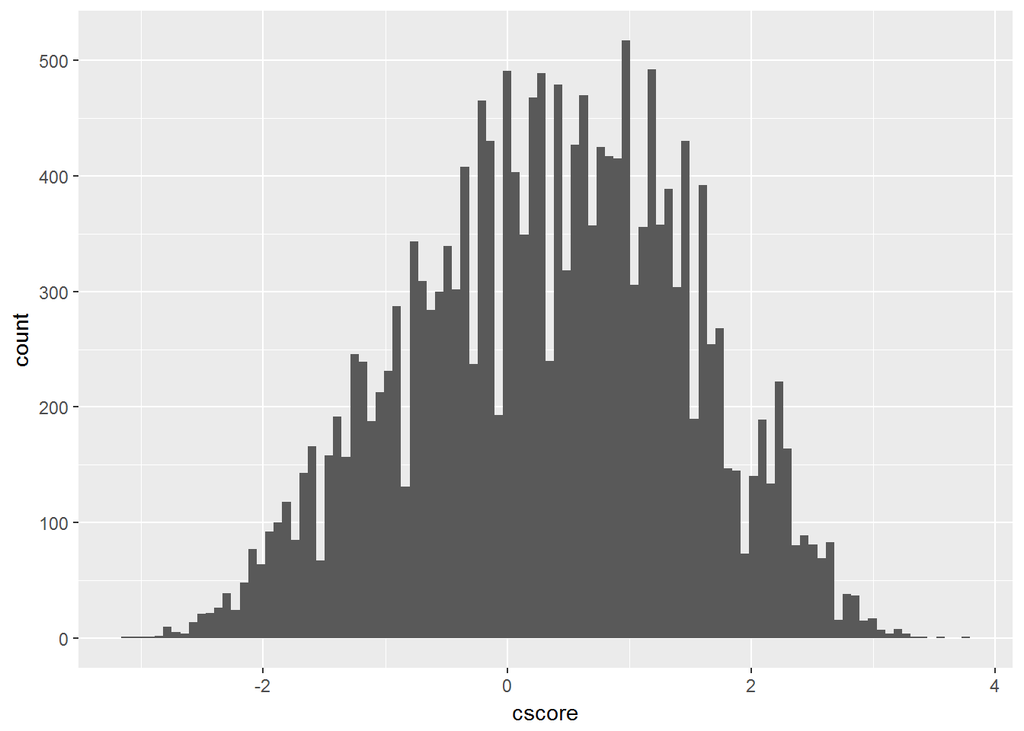

```r
ggplot(plotdf[plotdf$test_id == "ENGL", ],
       aes(x = cscore)) + geom_histogram(bins = 100)
```

You might wonder if you should use the cscore variable, rather than the scaled score, since it appears to correct for this problem. But you don’t know the details of how cscore was derived, and you saw in the correlation tables that it is missing for many tests. Even if the variable is fully populated for the tests you care about, as you have seen it might mask issues with those tests that you should be aware of. You are better off using the scaled scores and examining them carefully for the tests you are interested in. After examining the scaled scores, you can derive your own standardized scores and use them to compare scores across tests and years.

For now, drop the cscore variables, and make a note to yourself to inquire about their provenance. When making notes to yourself, it’s a good idea to prefix them with a consistent symbol so that you can find them quickly. Here the follow-up reminder is preceded by #TODO:

```r
assess$cscore <- NULL
assess$cscore_err <- NULL
```

# TODO: Check on cscore definitions

Clean the accommodation variable. The tabulation below demonstrates why it’s important to check distributions by school year! Note that students without accommodations have a missing value, rather than zero. You need to decide whether you trust the variable or not. Assuming the variable is reasonably accurate, it’s probably better to change the missing values to zero, or no, for the years when data is present. This will help distinguish the years that have no data. You should also clarify the scope of the variable in the variable label.

```r
table(assess$accommodation, useNA = "always")
```

```
##
##      1      Y   <NA>
##  11351  12368 424643
```

```r
table(assess$accommodation, assess$school_year, useNA = "always")
```

```
##
##         2006  2007  2008  2009  2010  <NA>
##   1        0     0     0     0 11351     0
##   Y        0     0     0 12368     0     0
##   <NA> 77712 83642 93740 89572 79977     0
```

```r
assess$accommodation[assess$accommodation == "Y"] <- "1"
assess$accommodation[is.na(assess$accommodation) &
                       assess$school_year > 2008] <- "0"
table(assess$accommodation, assess$school_year, useNA = "always")
```

```
##
##         2006  2007  2008  2009  2010  <NA>
##   0        0     0     0 89572 79977     0
##   1        0     0     0 12368 11351     0
##   <NA> 77712 83642 93740     0     0     0
```

```r
assess$accommodation <- as.numeric(assess$accommodation)
```

Finally, drop the `fake_data` indicator (after confirming that all the data is fake). You won’t have to do this with your own data, but with your own data you need to be mindful of confidentiality and Family Educational Rights and Privacy Act obligations.

```r
table(assess$fake_data, useNA = "always")
```

```
##
##      1   <NA>
## 448362      0
```

```r
assess$fake_data <- NULL
```

Browse the data. It looks much tidier now.

```r
View(assess)
```

## Restrict Sample

However, even though the variables have been examined and tidied up, we haven’t started to verify and clean up the structure of the data yet (we’ve dealt with the columns but not the rows). Start this process by seeing if there are any duplicate records using the `duplicated()` function - which tests for complete duplication of values by row across all columns in the dataset. Later we will test for duplication across only a subset of the measures in the data - but this is an easy first check.

The results of the `table()` function tell us how many rows are duplicated.

```r
table(duplicated(assess))
```

```
##
##  FALSE   TRUE
## 447389    973
```

```r
assess <- assess[!duplicated(assess), ] # 973 records dropped
```

Another good way to restrict the sample is to decide to exclude rows where data is missing on a key variable - in this case test scores. You might be inclined to keep the records with missing test scores, just to signal that a student was considered to be enrolled in the district. However, this data is being cleaned in preparation for merging with other cleaned data files, including student enrollment data.

Where there are conflicts, we’ll stipulate that the student enrollment data will take priority over the test score data in verifying student presence in the district. Thus the test records without scores won’t add useful information to the eventual analysis file, and dropping the empty records will help to simplify the file.

```r
table(is.na(assess$scale_score))
```

```
##
##  FALSE   TRUE
## 444347   3042
```

```r
prop.table(table(is.na(assess$scale_score)))
```

```
##
##       FALSE        TRUE
## 0.993200548 0.006799452
```

As we can see from the above, proportionally, missing test scores are a small fraction of our dataset. We can feel confident proceeding by dropping missing scale scores.

```r
assess <- assess[!is.na(assess$scale_score),]
# 3042 records
```

Next, restrict the sample to just the tests that you are interested in. First, let’s look at all the values of the `test_id` variable and see which we are interested in.

```r
sort(table(assess$test_id), decreasing=TRUE)
```

```
##
##  RD03  MA03  ALG1  MA05  ENGL  RD04  RD05  MA08  COMP  RD07  MA04  RD06
## 19363 19246 19234 18613 18531 18458 18321 18065 18038 18002 17902 17887
##  RD08  MA06  MA07  CECO  BIOL  USHI  GEOM  ALG2  WR10  SC05  SC08  MA3P
## 17773 17676 17399 17135 16893 14754 13961 13690 12868 12076 10937 10383
##  RD3P  WR04  WR07  CHEM  PSCI  CTAM  CSCM  CSPF  CTAR  PHYS  MA10  RD10
##  9924  8357  7887  5304  4658  2365  2351  2113  2079  1526   530    47
##  CSKA
##     1
```

You can see that most of the test IDs with the math and ELA subject prefixes also seem to include a grade level. There are two exceptions–the MA3P and RD3P tests, which occur in some but not all years. You can also see that there are very few 10th grade scores for the tests with the MA and RD prefixes, though there are subject specific tests such as GEOM and ENGL which likely correspond to upper grade level math and ELA courses. Check the distribution of MA and RD tests by year.

```r
assess %>% filter(grepl("MA|RD", test_id)) %>%
  select(test_id) %>% table %>% sort()
```

```
## .
##  RD10  MA10  RD3P  MA3P  MA07  MA06  RD08  RD06  MA04  RD07  MA08  RD05
##    47   530  9924 10383 17399 17676 17773 17887 17902 18002 18065 18321
##  RD04  MA05  MA03  RD03
## 18458 18613 19246 19363
```

We can use R’s string search capabilities to retain only the rows with these assessments. In this code we are selecting all rows of the data where the `test_id` variable contains either “RD” or “MA” as a character sequence. We use the `grepl()` function to convert this search into a TRUE/FALSE value that we can use to tell R which rows to keep (TRUE) and which to drop (FALSE).

You can see that most of the test IDs with the math and ELA subject prefixes also seem to include a grade level. There are two exceptions–the MA3P and RD3P tests, which occur in some but not all years. You can also see that there are very few 10th grade scores for the tests with the MA and RD prefixes, though there are subject specific tests such as GEOM and ENGL which likely correspond to upper grade level math and ELA courses. Check the distribution of MA and RD tests by year.

```r
assess %>% filter(grepl("MA|RD", test_id)) %>%
  select(test_id, school_year) %>% table
```

```
##        school_year
## test_id 2006 2007 2008 2009 2010
##    MA03 3088 3717 3896 4126 4419
##    MA04 3037 3246 3450 4062 4107
##    MA05 3098 3535 3754 4102 4124
##    MA06 3065 3192 3238 4034 4147
##    MA07 3018 3193 3268 3923 3997
##    MA08 2929 3450 3716 4055 3915
##    MA10  185  164  138   43    0
##    MA3P   29 3293 3505 3556    0
##    RD03 3073 3507 3531 4469 4783
##    RD04 2998 3220 3450 4380 4410
##    RD05 3040 3185 3367 4314 4415
##    RD06 3045 3164 3251 4209 4218
##    RD07 2990 3170 3256 4222 4364
##    RD08 2903 3169 3263 4262 4176
##    RD10   47    0    0    0    0
##    RD3P 3057 3312    0 3555    0
```

The counts for MA03 and RD03 are consistent with counts for other grades, which suggests that the RD3P and MA3P are additional tests, rather than substitutes, if they in fact correspond to 3rd grade tests. Check the months when the tests occur.

```r
tests_to_check <- c("RD3P", "RD03", "MA3P", "MA03")

assess %>% filter(test_id %in% tests_to_check) %>%
  select(test_date, test_id) %>% table
```

```
##             test_id
## test_date    MA03 MA3P RD03 RD3P
##   2005-09-01    0   29    0 3057
##   2006-05-01 2552    0 2543    0
##   2006-06-01  536    0  530    0
##   2006-09-01    0 3293    0 3312
##   2007-05-01 2993    0 2828    0
##   2007-06-01  724    0  679    0
##   2007-09-01    0 3505    0    0
##   2008-05-01 2155    0 1906    0
##   2008-06-01 1741    0 1625    0
##   2008-09-01    0 3556    0 3555
##   2009-05-01 1866    0 1870    0
##   2009-05-10  390    0  589    0
##   2009-06-01 1639    0 1636    0
##   2009-06-10  231    0  374    0
##   2010-05-01 1900    0 1896    0
##   2010-05-10  397    0  581    0
##   2010-06-01 1831    0 1821    0
##   2010-06-10  291    0  485    0
```

It looks like the “3P” tests are beginning of year pre-tests; make a note to yourself to verify this. This table helps us identify two types of tests that are not like the others. First, the `MA3P` and `RD3P` tests are always given on a different date than all of the other tests. This is a beginning of the year test (occurring in September). For our analysis, we are only interested in summative end-of-year tests so we should drop these observations. Second, very few `MA10` or `RD10` observations are observed – the counts are much lower than for all other tests. It is likely these observations represent a sepcial population, and they aren’t available consistently across test dates anyway - so let’s drop them as well.

An easy way to restrict the sample from here is to make a variable that holds the values of the `test_id` we want to retain:

```r
keep_tests <- c("MA03", "MA04", "MA05", "MA06", "MA07", "MA08",
                "RD03", "RD04", "RD05", "RD06", "RD07", "RD08")

assess <- assess[assess$test_id %in% keep_tests, ]
# 225,643 records dropped
```

This code uses the `%in%` operator, which will only retain values of `test_id` that match any element of our `keep_tests` vector.

## Simplify Structure

Your goal is to eventually restructure the data so that you have one record per student per year. What is the current structure of the data? You might expect that each student would take the state test in math and reading only once each year. Is this true? Check to see how many state tests students take each year using the duplicates function to see how many records there are for each student-year combination.

To manipulate the structure of the data, we will be making use of the data wrangling syntax in the `dplyr` package. This looks a little different than base R code, but allows us to use plain language to quickly build complex cross-tabulations and summaries of data that account for the grouped structure inherent in education data. Just remember that the `%>%` (pipe) operator can be read as “then”, and is used to pass a dataset from one side to the other.

You can read the code below as saying:

> Take the assess dataframe, then group it by student ID and school year. Then for each group create a summary variable called count_tests that counts the number of rows for each student ID and school_year. Then pull out the last variable in the dataset (count_tests) and create a table of values.

```r
assess %>% group_by(sid, school_year) %>%
  summarize(count_tests = n()) %>% pull %>% table
```

```
## .
##     1     2     3     4     5     6
##  1901 83364  9115  5605    49    11
```

From this, we can see that most students have two tests, but some students only have 1 test score, and others have 3 or more. Now, let’s see how this breaks down by each test. Notice how this code differs only slightly from above.

```r
assess %>% group_by(sid, school_year, test_id) %>%
  summarize(count_tests = n()) %>% pull %>% table
```

```
## .
##      1      2      3
## 176420  20817    217
```

Based on the output of this command, there are about 42 thousand records which have duplicated student ID, school year, and test_id values, or about 21,000 thousand “extra” records. Are these because of test taking on multiple test dates?

```r
assess %>% group_by(sid, school_year, test_id, test_date) %>%
  summarize(count_tests = n()) %>% pull %>% table
```

```
## .
##      1      2      3
## 212749   2663    210
```

This shows that there are a large handful of cases (all values > 1) where students took the same test on the same date. We know these records aren’t exactly the same, because we already dropped duplicate records. A common strategy is to create a variable indicating these records and then to visually inspect them.

The only difference in this code from that above is that we want to modify our dataframe, so we include the `assess <-` part to tell R we want to overwrite the `assess` dataframe with the changes we make. We also include `as.data.frame` at the end of our sequence of transformations - this is a best practice to ensure that the dataset is still compatible with all of the other analysis techniques we have learned above.

```r
assess <- assess %>% group_by(sid, school_year, test_id, test_date) %>%
  mutate(tag = n()) %>% ungroup %>%
  as.data.frame

table(assess$tag)
```

```
##
##      1      2      3
## 212749   5326    630
```

```r
View(assess[assess$tag > 1,])
```

It looks as if there are a number of cases where students have multiple test instances on the same day, but different scores. This is an implausible situation. It may relate to data errors. How should you handle this? You could reach out to the district’s assessment department to discover why there are so many near-duplicate records, but getting an answer to your query will take time, and might not fully resolve the issue. Should you ask for a new data pull? You could consider doing so. But the “extra” near-duplicate records make up only 1.4 percent of the total records.

If you believe that most of the student data is accurate, having inaccurate data for one or two percent of your dataset is unlikely to bias your results if you are interested in analyzing patterns in the data rather than developing individual accountability results. Rather than calling a halt to the data cleaning work, it makes sense to proceed by applying a decision rule to choose a single test score record in cases where there are near-duplicates.

This choice demonstrates three data cleaning truisms. First, you are often faced with making a tradeoff between losing some information and developing a tractable dataset. Second, education data is of varying, and often poor, quality. The timeline for your analysis project is probably shorter than the timeline for improving data governance, data collection, and data management in your organization. Nonetheless, even imperfect data can yield meaningful and actionable information, and using that data in analysis will help to create the demand for better-quality data over time. And third, it’s always a good idea to learn as much as you can about the data you are working with from others who know it better. You may not be able to get answers right away, though, so you should comment and organize your cleaning code so that you can modify it easily when or if you learn more about the data, and re-run it easily if you receive updated data.

Before starting to apply decision rules to pick specific test instances, check to see if there are any cases where the test scores, test IDs, and test dates are all the same, and some other variable is different.

```r
table(duplicated(assess[, c("sid", "school_year", "test_id", "test_date",
                            "scale_score")]))
```

```
##
##  FALSE
## 218705
```

So, the data is unique at the student-year-test-date-score level.

Another use of nvals for this data is to check how many test dates there are for a given test id.

```r
assess %>% group_by(test_id, school_year) %>%
  summarize(count = n_distinct(test_date)) %>%
  pull %>% table
```

```
## .
##  2  4
## 36 24
```

This is interesting–there are either two or four test dates for a given test in a given year. Is there a pattern by school year?

```r
assess %>% group_by(test_id, school_year) %>%
  summarize(count = n_distinct(test_date)) %>%
  ungroup %>%
  select(school_year, count) %>%
  table
```

```
##            count
## school_year  2  4
##        2006 12  0
##        2007 12  0
##        2008 12  0
##        2009  0 12
##        2010  0 12
```

In fact, there is. Part of data cleaning is making sure that the ranges of values for variables are reasonable, and though we reformatted the test date variable, we waited to inspect it in detail. This is partly because test dates are especially relevant to the “row cleaning” aspect of test data cleaning, and partly because examining test dates is easier now that there are fewer tests. Check the distribution of test dates by test ID. They look reasonable. All the test dates are in May or June, and there are two test dates in early years and four test dates in later years.

```r
table(assess$test_date, assess$test_id, useNA = "always")
```

```
##
##              MA03 MA04 MA05 MA06 MA07 MA08 RD03 RD04 RD05 RD06 RD07 RD08
##   2006-05-01 2552 2527 2541 2472 2534 2449 2543 2492 2498 2456 2508 2423
##   2006-06-01  536  510  557  593  484  480  530  506  542  589  482  480
##   2007-05-01 2993 2579 2826 2628 2658 2865 2828 2564 2547 2610 2641 2615
##   2007-06-01  724  667  709  564  535  585  679  656  638  554  529  554
##   2008-05-01 2155 1941 2086 2226 2265 2643 1906 1945 1834 2238 2257 2278
##   2008-06-01 1741 1509 1668 1012 1003 1073 1625 1505 1533 1013  999  985
##   2009-05-01 1866 1831 1913 2338 2375 2409 1870 1810 1875 2335 2375 2394
##   2009-05-10  390  317  397  470  493  550  589  504  559  573  693  703
##   2009-06-01 1639 1688 1551 1080  913  945 1636 1676 1523 1089  914  941
##   2009-06-10  231  226  241  146  142  151  374  390  357  212  240  224
##   2010-05-01 1900 1883 1826 2315 2219 2241 1896 1863 1818 2305 2213 2230
##   2010-05-10  397  327  335  483  412  415  581  530  520  529  666  599
##   2010-06-01 1831 1657 1718 1170 1209 1097 1821 1649 1699 1169 1198 1091
##   2010-06-10  291  240  245  179  157  162  485  368  378  215  287  256
##   <NA>          0    0    0    0    0    0    0    0    0    0    0    0
##
##              <NA>
##   2006-05-01    0
##   2006-06-01    0
##   2007-05-01    0
##   2007-06-01    0
##   2008-05-01    0
##   2008-06-01    0
##   2009-05-01    0
##   2009-05-10    0
##   2009-06-01    0
##   2009-06-10    0
##   2010-05-01    0
##   2010-05-10    0
##   2010-06-01    0
##   2010-06-10    0
##   <NA>          0
```

If you followed the logic behind the duplicates functions above and the review of test dates, at this point you should have a fairly good sense of the structure of the test data. Now we can begin applying decision rules to simplify that structre. This will mostly involve deciding to keep a single test record out of various groups of near-duplicates.

First, let’s deal with the cases where there are multiple scores for a given test on the same test date. We’ll decide arbitrarily to keep the highest score in these cases. Business rules are all about making decisions that are easy to explain that reduce the complexity in the data. Other decision rules might include taking the most recent score, or taking the average of the two scores. The specific rule may vary from domain to domain, but the goal is to reduce the data down to the level of uniqueness we need for our analysis.

To do this, we’ll use the `group_by()` function and create an intermediate variable indicating the highest score of `scale_score` for each combination of student, school year, test ID, date.

```r
assess <- assess %>% group_by(sid, school_year, test_id, test_date) %>%
  mutate(keep = if_else(scale_score == max(scale_score), 1, 0)) %>%
  as.data.frame()

assess <- assess[assess$keep == 1, ] # drop 3,083 records
assess$keep <- NULL
```

Now, we’ll decide to keep the record from the earliest test date, using similar syntax. Here the first record of each group is kept.

```r
assess <- assess %>% group_by(sid, school_year, test_id) %>%
  mutate(keep = if_else(test_date == min(test_date), 1, 0)) %>%
  filter(keep == 1) %>%
  as.data.frame()

# 18,168 records dropped
```

```r
table(duplicated(assess[, c("sid", "school_year", "test_id")]))
```

```
##
##  FALSE
## 197454
```

Just like that, we now have only one record per student, school year, and test ID. Check the distribution of records across school years. The growth across school years is more even than before, without the jump in the number of test instances in 2009.

```r
table(assess$test_id, assess$school_year, useNA = "always")
```

```
##
##        2006 2007 2008 2009 2010 <NA>
##   MA03 3087 3327 3529 3509 3732    0
##   MA04 3037 3246 3450 3524 3541    0
##   MA05 3093 3158 3399 3472 3544    0
##   MA06 3062 3192 3238 3422 3486    0
##   MA07 3016 3193 3268 3297 3428    0
##   MA08 2928 3079 3283 3357 3339    0
##   RD03 3071 3263 3447 3515 3717    0
##   RD04 2998 3220 3450 3488 3513    0
##   RD05 3038 3035 3290 3423 3521    0
##   RD06 3043 3164 3251 3427 3474    0
##   RD07 2988 3170 3256 3296 3411    0
##   RD08 2903 3000 3174 3346 3326    0
##   <NA>    0    0    0    0    0    0
```

We’re getting very close to being able to reshape the test score data so that there is one record per student and year, with math and reading scores for each year. However, we haven’t dealt with possible cases where students took more than one type of reading or math test (ie, multiple tests for the same subject but for different grade levels) in a given year. We also don’t know if there are any students who took tests for different subjects at different grade levels. To help with these last checks and get the data ready for reshaping, parse the test ID to define variables for test grade level and test subject.

To do this, we will use the `substr()` function to extract the subject, first two characters, and then the grade - third and fourth characters.

```r
assess$test_subject <- substr(assess$test_id, 1, 2)
table(assess$test_subject, assess$test_id, useNA = "always")
```

```
##
##         MA03  MA04  MA05  MA06  MA07  MA08  RD03  RD04  RD05  RD06  RD07
##   MA   17184 16798 16666 16400 16202 15986     0     0     0     0     0
##   RD       0     0     0     0     0     0 17013 16669 16307 16359 16121
##   <NA>     0     0     0     0     0     0     0     0     0     0     0
##
##         RD08  <NA>
##   MA       0     0
##   RD   15749     0
##   <NA>     0     0
```

```r
assess$test_grade <- as.numeric(
  substr(assess$test_id, 3,4)
)
table(assess$test_grade, assess$test_id, useNA = "always")
```

```
##
##         MA03  MA04  MA05  MA06  MA07  MA08  RD03  RD04  RD05  RD06  RD07
##   3    17184     0     0     0     0     0 17013     0     0     0     0
##   4        0 16798     0     0     0     0     0 16669     0     0     0
##   5        0     0 16666     0     0     0     0     0 16307     0     0
##   6        0     0     0 16400     0     0     0     0     0 16359     0
##   7        0     0     0     0 16202     0     0     0     0     0 16121
##   8        0     0     0     0     0 15986     0     0     0     0     0
##   <NA>     0     0     0     0     0     0     0     0     0     0     0
##
##         RD08  <NA>
##   3        0     0
##   4        0     0
##   5        0     0
##   6        0     0
##   7        0     0
##   8    15749     0
##   <NA>     0     0
```

Check for cases of students taking a test in multiple grades. There is only one such case–one student took both 7th and 8th grade math tests along with a 7th grade reading test.

```r
assess %>% group_by(sid, school_year) %>%
  mutate(count = n_distinct(test_id)) %>%
  filter(count > 2) %>% as.data.frame %>% print
```

```
##         sid school_year test_id  test_date ach_level accommodation
## 1 131210412        2008    MA07 2008-05-01    Novice            NA
## 2 131210412        2008    MA08 2008-05-01    Novice            NA
## 3 131210412        2008    RD07 2008-05-01    Novice            NA
##   scale_score tag keep test_subject test_grade count
## 1         332   1    1           MA          7     3
## 2         345   2    1           MA          8     3
## 3         340   1    1           RD          7     3
```

Check for cases of students taking a test in multiple grades. There is only one such case–one student took both 7th and 8th grade math tests along with a 7th grade reading test.

```r
assess %>% group_by(sid, school_year) %>%
  mutate(grade_count = n_distinct(test_grade)) %>%
  pull %>% table
```

```
## .
##      1      2
## 197451      3
```

If there were many cases like this, we might want to merge the test data with student enrollment data to get the students’ actual enrolled grades. However, only one record needs to be dropped. Decide to keep the test score for the lower grade, since that will lead to the student having the same grade level for reading and math.

```r
assess <- assess %>% group_by(sid, school_year) %>%
  mutate(keep = if_else(test_grade == min(test_grade), 1, 0)) %>%
  ungroup %>% filter(keep == 1) %>% as.data.frame
```

At this point we can drop the test ID and test date variables, and get ready to reshape the data.

```r
keep_vars <- c("sid", "school_year", "test_grade", "test_subject",
               "scale_score", "ach_level", "accommodation")
assess <- assess[, keep_vars]
```

Just to verify: for a given student and year, there is no more than one test record per subject.

```r
nrow(distinct(assess, sid, school_year, test_subject)) == nrow(assess)
```

```
## [1] TRUE
```

Finally, are there any cases of students with math and ELA tests for different grade levels? If so, we might need to have separate variables for math test grade level and ELA test grade level after reshaping the data, at least until the test scores have been standardized by grade and year. Fortunately there are no such instances.

```r
assess %>% group_by(sid, school_year) %>%
  summarize(nvals_tg = n_distinct(test_grade)) %>%
  pull(nvals_tg) %>% table
```

```
## .
##      1
## 100045
```

## Reshape the Data

The data is currently in long format, with one record per student, year and subject, and one test score per record. We want to convert it to wide format, with one record per student and year, but two test score variables, one for each subject. This will make it easy to merge the test score dataset later with a student dataset that has annual information about student school enrollment, demographics, and program participation. We can do this using R’s `reshape()` function.

First, let’s see how many records we expect if there is one record per student per year:

```r
nrow(distinct(assess, sid, school_year))
```

```
## [1] 100045
```

The logic behind the reshape function is complicated. Most of the R functions demonstrated in this tutorial will probably start to feel intuitive with experience, but it is harder to get the syntax for reshape correct on the first try. Before reshaping data, take a few deep breaths, clear your mind of distractions, and make sure you have the help page for reshape displayed by typing `?reshape`

Since we’re reshaping wide by test subject, the test subject values will become suffixes for the variables that vary by test subject. Change the values so they will work well as suffixes.

```r
assess$test_subject[assess$test_subject == "RD"] <- "e"
assess$test_subject[assess$test_subject == "MA"] <- "m"
```

Now, do the reshape. First we give the `reshape()` function our dataset, then we tell it we intend to shape our data wide. The `v.names` argument tells it which variables we expect to be shaped wide, that is, these single columns will become multiple columns with suffixes. The `timevar` argument tells R which variable to get the column suffixes from. And the `idvar` argument tells R which columns identify a unique row in the reshaped dataset. Finally, the `sep` argument specifies how R pastes together the column names and the values of `timevar` to create new variables, by specifying the `_` character as the separator between the column name and the suffix.

```r
wide_data <- reshape(assess, direction = "wide",
                     v.names = c("scale_score", "ach_level",
                                    "accommodation"),
                     timevar = "test_subject",
                     idvar = c("sid", "school_year", "test_grade"),
                     sep = "_")
names(wide_data)
```

```
## [1] "sid"             "school_year"     "test_grade"      "scale_score_m"
## [5] "ach_level_m"     "accommodation_m" "scale_score_e"   "ach_level_e"
## [9] "accommodation_e"
```

We have now created a new data frame called `wide_data`, which contains the same information as before, but now reshaped wide. Look at how the names of the variables have changed.

The `wide_data` is now unique at the student and year level. Do some tidying up.

```r
wide_data <- wide_data[, c("sid", "school_year", "test_grade", "scale_score_m",
                     "scale_score_e", "ach_level_m", "ach_level_e",
                     "accommodation_m", "accommodation_e")]
```

We’ve made a clean, tidy dataset, and simplified and restructured it the way we wanted, but we’ve ignored the single most important set of values: the actual test scores. In real life, you’d probably check the distribution of test scores in the raw data long before you started cleaning the dataset. Instead, we’ve saved it here until the end. These commands will generate a set of histograms by subject, year, and grade level.

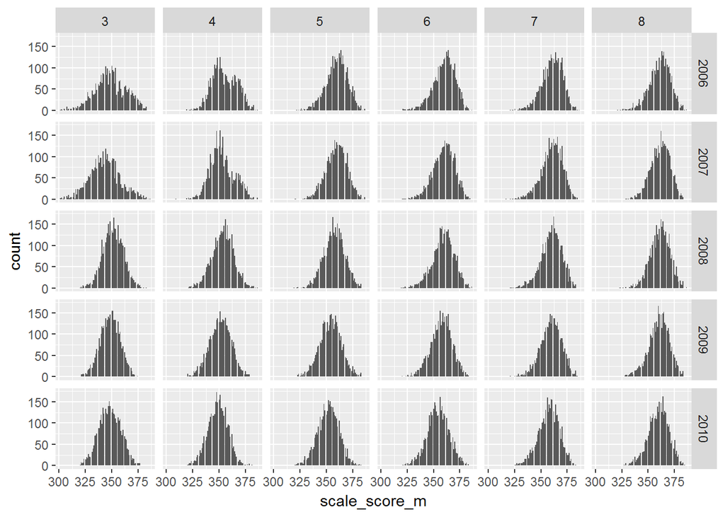

```r
library(ggplot2)

ggplot(wide_data, aes(x = scale_score_m)) + geom_histogram(bins = 100) +
  facet_grid(school_year~test_grade)
```

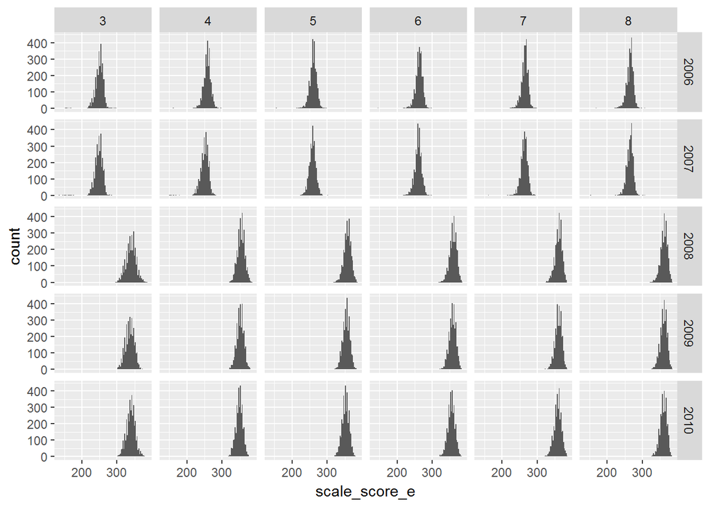

```r
ggplot(wide_data, aes(x = scale_score_e)) + geom_histogram(bins = 100) +
  facet_grid(school_year~test_grade)
```

After reviewing the histograms, if you feel reasonably comfortable using the scores as measures of student outcomes, you can standardize them by subtracting the mean and dividing by the standard deviation for each subject, grade, and year. This will convert the test scores to standard deviation units with a mean of zero and a standard deviation of one, so that you can compare results for different tests. The `scale()` function in R makes this convenient.

```r
wide_data <- wide_data %>% group_by(school_year, test_grade) %>%
  mutate(scale_score_std_e = scale(scale_score_e),
         scale_score_std_m = scale(scale_score_m)) %>%
  as.data.frame

wide_data %>% select(starts_with("scale_score")) %>% summary
```

```
##  scale_score_m   scale_score_e   scale_score_std_e  scale_score_std_m
##  Min.   :301.0   Min.   :137.0   Min.   :-12.3333   Min.   :-4.4146
##  1st Qu.:348.0   1st Qu.:264.0   1st Qu.: -0.6148   1st Qu.:-0.6428
##  Median :356.0   Median :343.0   Median :  0.0648   Median : 0.0414
##  Mean   :355.8   Mean   :317.7   Mean   :  0.0000   Mean   : 0.0000
##  3rd Qu.:364.0   3rd Qu.:358.0   3rd Qu.:  0.6673   3rd Qu.: 0.6955
##  Max.   :386.0   Max.   :386.0   Max.   :  4.7443   Max.   : 3.4131
##  NA's   :810     NA's   :1827    NA's   :1827       NA's   :810
```

Bonus question - why do we have missing data for some of our assessment scorew now after we dropped all missing score values above?

## Save the Cleaned Data File

Finally, save your cleaned test score file.

```r
save(wide_data, file = "data/test_scores_clean.rda")
```